# **Asthma Exacerbation Prediction from Wearable Heart Rate**

**TL;DR —** Built a temporal machine learning pipeline to forecast near-term asthma exacerbations using both **passive smartwatch heart rate** and **active questionnaire** data.  
Structured framework: **7-day lookback → 2-day buffer → 3-day horizon**.  
Models: **Logistic Regression baseline** and **XGBoost (interpreted with SHAP)**.  
**Headline results (test set):** Active model AUROC = 0.84 / AUPRC = 0.65; Passive HR model AUROC = 0.76 / AUPRC = 0.49.

[Back to repository](https://github.com/cianmcguinn/asthma-exacerbation-wearables)

**Jump to:**  
Problem • Reproducibility • Data and Cohort • Leakage Control and Splits • Feature Engineering • Models and Tuning • Results • Interpretability • Sensitivity Analyses • Limitations

This page is an HTML summary exported from the project notebook for easier viewing of results and figures.

## **Problem**

Asthma affects **260 million people** worldwide and causes around **455 000 deaths each year**.  
Most care remains **reactive** — treatment starts *after* symptoms worsen.  
These acute flare-ups (exacerbations) drive most hospital admissions and NHS costs.

### **Why prediction is difficult**

Current early-warning systems rely on:

- **Symptom diaries** → subjective and often incomplete
- **Electronic health records** → sparse, irregular, and not real-time

Both approaches miss subtle, day-to-day physiological changes that occur *before* an attack.

### **Why wearables might help**

Smartwatches collect continuous, objective data with no patient effort.  
Among these signals, **heart rate (HR)** may reflect early loss of asthma control — yet its **stand-alone predictive power** is unknown.

### **This project**

This study builds a **temporal machine-learning pipeline** to forecast asthma exacerbations using:

- **Passive smartwatch HR** (physiology)
- **Active questionnaire data** (symptoms & medication use)

The aim is to test how well HR alone can predict risk and whether it could support **scalable, low-burden asthma monitoring** in real-world care.

## **Reproducibility**

All results are fully reproducible from the same notebook using fixed random seeds and consistent parameters.  
The code defines a single configuration for the **lookback**, **buffer**, and **horizon**, applies the same data splits, and regenerates all figures and tables automatically.

Run configuration

| Setting | Value |
| --- | --- |
| Seed | 42 |
| Lookback / Buffer / Horizon (days) | 7 / 2 / 3 |
| Outcome source | inhaler |
| Outcome definition | primary |
| Threshold policy | f1 (target=0.5) |
| Imbalance method | None |
| Scaling | None |
| HR min coverage (fraction of valid minutes/day) | 0.5 |
| FFILL limit (passive, days) | 3 |

Pinned packages

| Package | Version |
| --- | --- |
| Python | 3.12.12 |
| matplotlib | 3.10.0 |
| numpy | 2.0.2 |
| pandas | 2.2.2 |
| scikit-learn | 1.6.1 |
| scipy | 1.16.2 |
| shap | 0.49.1 |
| xgboost | 3.0.5 |

## **Data & Cohort**

This project used the **AAMOS-00** dataset — a UK study of **22 adults with severe asthma** monitored for up to six months.  
Each participant contributed data from three digital sources:

| Stream | Data type | Description | Median coverage |
| --- | --- | --- | --- |
| **Smartwatch** | Heart rate, steps, activity | Continuous minute-level physiology | ~57% of study days |
| **Smart inhaler** | Actuation events | Objective reliever-use logs | ~23% of study days |
| **Questionnaires** | Symptoms, medication, triggers | Daily self-reports | ~60% of study days |

**Outcome:** days with elevated reliever use (relative to each participant’s baseline).  
**Predictors:** passive HR features (variability, circadian averages) and active questionnaire items (symptoms, reliever use, triggers).

HR: 2,101,829 rows • 7 cols

Inhaler: 2,904 rows • 4 cols

Questionnaire: 1,583 rows • 8 cols

Smartwatch (HR, steps, activity)

20 participants

1,567 total days • 57.3% complete

Inhaler use

17 participants

694 total days • 22.8% complete

Questionnaire

22 participants

1,583 total days • 59.9% complete

Table 2 — Dataset summary (before pre-processing)

| stream | participants | total_days | median_days | IQR_low | IQR_high | min_days | max_days | mean % completeness |
| --- | --- | --- | --- | --- | --- | --- | --- | --- |
| Smartwatch (HR, steps, activity) | 20 | 1567 | 58 | 7 | 131 | 0 | 179 | 57.3 |
| Inhaler use | 17 | 694 | 10 | 1 | 30 | 0 | 183 | 22.8 |
| Questionnaire | 22 | 1583 | 52 | 19 | 126 | 2 | 173 | 59.9 |

### **Pre-processing**

Data were cleaned, harmonised, and aligned to a **dense daily calendar** per user:

- Implausible HR values clipped (<30 or >220 bpm)
- Daily HR summaries derived (mean, min, max, variability, circadian bins)
- Questionnaire items harmonised and forward-filled for short gaps (≤3 days)
- Inhaler data collapsed to daily counts
- Participants with fewer than two reliever uses excluded

All streams were merged into consistent **per-person, per-day records**, ready for temporal windowing.

**View helper functions (optional)**

| Helper | Purpose (one-line) | Inputs | Key outputs |
| --- | --- | --- | --- |
| `clean_passive_hr` | Clean and summarise HR minute-level data. | HR CSVs | `hr_min` |
| `make_user_calendar` | Build dense daily timeline per user. | Inhaler events | `calendar` |
| `filter_inhaler_users_with_min_uses` | Retain users with ≥2 reliever uses. | Inhaler events | Filtered inhaler |
| `clean_active_questionnaire` | Harmonise names/dtypes; derive medication fields. | Questionnaire CSV | Cleaned daily data |
| `align_active_to_calendar` | Align questionnaire to dense calendar; forward-fill short gaps. | Cleaned DQ, `calendar` | `ACTIVE_DAILY` |

`hr_min` 1,952,194 × 8`inh_daily` 1,572 × 3

Passive (wearables)

16 participants

HR implausible flagged: 2,835 • HR NaNs after: 534,563

Questionnaire rows aligned to the inhaler calendar; missing feature days imputed by forward-fill up to 3 days.

['`ACTIVE_DAILY` 1,572 × 11', 'observed days (raw): 1,583', 'imputed days: 554', 'post-align coverage: 64.8%']

Active alignment

FFILL

missing days before: 554 (limit 3d)

## **Leakage Control & Splits**

All data were split **within each user** and in **chronological order** to prevent information leakage between training, validation, and test sets.  
This ensures that lookback, buffer, and horizon windows never cross split boundaries.

### **Chronological per-user splits**

- The function `split_timelines()` walks each user’s daily calendar and assigns windows to **train**, **validation**, and **test** sets using fixed ratios (`CFG.TRAIN_RATIO`, `CFG.VAL_RATIO`).
- Users with too few windows (`< CFG.MIN_USER_WINDOWS_TRAIN_ONLY`) are placed in **train-only**.
- The resulting masks are **disjoint** and **exhaustive**, covering 100% of available days.

Per-user day counts by split (first 5 users)

| test | train | val |
| --- | --- | --- |
| 45 | 106 | 27 |
| 0 | 19 | 0 |
| 28 | 67 | 17 |
| 48 | 114 | 28 |
| 16 | 37 | 10 |

### **Anchor generation (L–B–H framing)**

To maintain temporal integrity, anchor indices were built per user with the following window structure:

| Segment | Definition |
| --- | --- |
| **Lookback (L)** | `t−L … t−1` |
| **Buffer (B)** | `t … t+B−1` |
| **Horizon (H)** | `t+B … t+B+H−1` |

Each anchor is computed **within its assigned split**, ensuring no overlap across train/val/test.

Anchor counts by split

| n_anchors |
| --- |
| 778 |
| 99 |
| 248 |

Example anchors (first 3 per split)

| split | user_key | t_date | lb_start_idx | lb_end_idx | buf_start_idx | buf_end_idx | hz_start_idx | hz_end_idx |
| --- | --- | --- | --- | --- | --- | --- | --- | --- |
| train | 113 | 7 | 0 | 6 | 7 | 8 | 9 | 11 |
| train | 113 | 8 | 1 | 7 | 8 | 9 | 10 | 12 |
| train | 113 | 9 | 2 | 8 | 9 | 10 | 11 | 13 |
| val | 113 | 113 | 106 | 112 | 113 | 114 | 115 | 117 |
| val | 113 | 114 | 107 | 113 | 114 | 115 | 116 | 118 |
| val | 113 | 115 | 108 | 114 | 115 | 116 | 117 | 119 |
| test | 113 | 140 | 133 | 139 | 140 | 141 | 142 | 144 |
| test | 113 | 141 | 134 | 140 | 141 | 142 | 143 | 145 |
| test | 113 | 142 | 135 | 141 | 142 | 143 | 144 | 146 |

With anchors defined, **features are aggregated over the lookback**, enforced by the **buffer**, and labelled in the **horizon**, creating fully leakage-safe training data.

### **HR coverage - sensitivity test**

A sensitivity filter was applied to include only users with adequate HR completeness:

- A day is valid if ≥ `CFG.HR_MIN_COVERAGE` of minute-level HR readings are present.
- Users must have at least `CFG.MIN_HR_DAYS_PER_USER` valid HR days to be retained.
- This same subset is used consistently across all splits.

## **Feature Engineering**

This section transforms raw wearable and questionnaire data into **model-ready feature matrices**.  
Steps include daily signal derivation, 7-day temporal rollups, outcome labelling, and feature selection.

### **Daily feature derivation**

**Passive (smartwatch)** — From minute-level HR, steps, and activity logs:

- Derived HR metrics (mean, min, max, SDNN, RMSSD, abrupt-change flags)
- Circadian averages (night, morning, afternoon, evening)
- Activity fractions (active, sedentary, sleep) and total steps
- Valid-data ratio (**HR coverage**)  
  Gaps were forward-filled up to `CFG.FFILL_LIMIT_DAYS`.

**Active (questionnaire)** — From daily self-reports:

- Night/day symptoms, activity limitation, preventer use, reliever use, and triggers
- Derived medication adherence (`preventer_delta`) and previous-day reliever use (`reliever_prev1`)
- Aligned to the dense per-user calendar with constrained forward-fill (≤3 days)

passive train: rows=778 • features=135

passive val: rows=99 • features=135

passive test: rows=248 • features=135

active train: rows=576 • features=63

active val: rows=67 • features=63

active test: rows=137 • features=63

### **7-day temporal rollups**

For each anchor day *t*, features were aggregated across the **7-day lookback** window:  
`mean`, `median`, `max`, `min`, `range`, `std`, `skew`, `slope`, and `last`.  
Active features required ≥50% observed days within the window.

**Outputs:**

- Passive matrices: 778 / 99 / 248 rows with 135 features each (train/val/test)
- Active matrices: 576 / 67 / 137 rows with 63 features each

### **Daily variables and descriptives**

| Model | Daily variable | Columns | Type | Unit/scale | Description | coverage_% |
| --- | --- | --- | --- | --- | --- | --- |
| Passive | HR (central tendency) | mean_hr, min_hr, max_hr | numeric | bpm | Daily HR summary | 69.500000 |
| Passive | HR (variability) | std_hr, abrupt_hr_changes, rmssd_hr | numeric | bpm / count | HR variation & abrupt changes | 69.500000 |
| Passive | Circadian HR (4 bins) | hr_night_mean, hr_morning_mean, hr_afternoon_mean, hr_evening_mean | numeric | bpm | Night/Morning/Afternoon/Evening | 69.500000 |
| Passive | Activity fractions | frac_active, frac_sedentary, frac_sleep, frac_unknown | proportion | 0–1 | Sleep/Sedentary/Active/Unknown | 69.500000 |
| Passive | Steps total | steps_total | numeric | steps/day | Daily steps | 69.500000 |
| Passive | HR coverage | hr_coverage | proportion | 0–1 | Valid HR minutes in day | 74.300000 |
| Active | Night-time symptoms | daily_night_symp | binary | 0/1 | Self-report | 82.100000 |
| Active | Day-time symptoms | daily_day_symp | binary | 0/1 | Self-report | 82.100000 |
| Active | Activity limitation | daily_limit_activity | binary | 0/1 | Self-report | 82.100000 |
| Active | Preventer taken | preventer_taken | binary | 0/1 | Self-report | 82.100000 |
| Active | Preventer delta | preventer_delta | ordinal | −1/0/+1 | Less/usual/more | 78.800000 |
| Active | Trigger exposures | daily_triggers | count | events/day | Self-report | 45.400000 |
| Active | Reliever use (prev day) | reliever_prev1 | count | puffs/day | Lag-1 | 77.400000 |

| Domain | Variable | Unit | median | IQR_low | IQR_high | min | max |
| --- | --- | --- | --- | --- | --- | --- | --- |
| Smartwatch | Heart rate (daily mean) | bpm | 85.901661 | 79.931393 | 87.730302 | 72.733101 | 90.968468 |
| Smartwatch | Steps per day | steps/day | 5956.750000 | 4029.375000 | 7814.250000 | 1078.500000 | 14951.000000 |
| Smartwatch | Activity type (sleep/sedentary/active/unknown) | - |  |  |  |  |  |
| Questionnaire | Night-time symptoms (% of days) | % of observed days | 2.631579 | 0.000000 | 22.203224 | 0.000000 | 77.456647 |
| Questionnaire | Day-time symptoms (% of days) | % of observed days | 100.000000 | 57.481540 | 100.000000 | 6.250000 | 100.000000 |
| Questionnaire | Activity limitation (% of days) | % of observed days | 20.974547 | 0.000000 | 75.316456 | 0.000000 | 100.000000 |
| Questionnaire | Trigger exposures (% of days ≥1) | % of observed days | 71.159863 | 43.279570 | 100.000000 | 0.000000 | 100.000000 |
| Questionnaire | Preventer taken (% of days) | % of observed days | 100.000000 | 100.000000 | 100.000000 | 50.000000 | 100.000000 |
| Questionnaire | Preventer delta (median) | 1–5 (median across users) | 0.000000 | 0.000000 | 0.000000 | -1.000000 | 0.000000 |
| Questionnaire | Reliever use (prev day, median) | puffs/day (median across users) | 1.000000 | 0.000000 | 1.500000 | 0.000000 | 5.000000 |

### **Outcome definition**

Labels were generated per anchor using the same **lookback–buffer–horizon (L–B–H)** structure:

- **Primary:** 1 if ≥ 2 days in the horizon exceed the user’s baseline reliever use
- **Alternative:** 1 if any two *consecutive* days exceed baseline

Each user’s baseline was calculated from **train-only** days to avoid leakage.

train: labels=778 / anchors=778 (100.0%)

val: labels=99 / anchors=99 (100.0%)

test: labels=248 / anchors=248 (100.0%)

### **Event trends**

Average HR rose in the days leading up to an exacerbation.  
The plot below shows mean ± 95 % CI HR deviation from baseline, centred at event onset (t = 0).

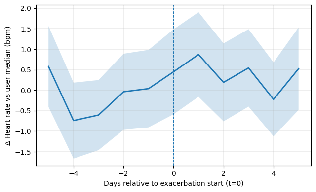

### **Window and class balance summaries**

Assembled matrices: size and class balance

| model | split | windows (n) | features (n) | positives (n) | % positive |
| --- | --- | --- | --- | --- | --- |
| Passive | Train | 778 | 135 | 217 | 27.900000 |
| Passive | Val | 99 | 135 | 17 | 17.200000 |
| Passive | Test | 248 | 135 | 32 | 12.900000 |
| Active | Train | 576 | 63 | 192 | 33.300000 |
| Active | Val | 67 | 63 | 13 | 19.400000 |
| Active | Test | 137 | 63 | 29 | 21.200000 |

Passive windows: 1125Active windows: 780

Table 4 — Passive: participant & window summary

| metric | median | IQR low | IQR high | min | max |
| --- | --- | --- | --- | --- | --- |
| train_windows | 47 | 21 | 96 | 2 | 103 |
| val_windows | 16 | 5 | 16 | 3 | 17 |
| test_windows | 16 | 10 | 35 | 1 | 37 |
| total_windows | 64 | 24 | 146 | 2 | 157 |

Table 4 — Active: participant & window summary

| metric | median | IQR low | IQR high | min | max |
| --- | --- | --- | --- | --- | --- |
| train_windows | 43 | 9 | 82 | 2 | 98 |
| val_windows | 10 | 3 | 16 | 2 | 17 |
| test_windows | 14 | 8 | 34 | 2 | 37 |
| total_windows | 58 | 11 | 107 | 2 | 152 |

Table 3a — Passive: split summary

| split | users (n) | windows (n) |
| --- | --- | --- |
| Train | 15 | 778 |
| Val | 9 | 99 |
| Test | 12 | 248 |

Table 3a — Active: split summary

| split | users (n) | windows (n) |
| --- | --- | --- |
| Train | 13 | 576 |
| Val | 7 | 67 |
| Test | 7 | 137 |

### **Feature selection (train-only)**

Two-step filtering, applied **only on the training split**:

1. **Variance filter:** remove near-constant columns (`var < threshold`)
2. **Correlation pruning:** drop one of each pair with |r| ≥ `CFG.CORR_RHO_MAX`, keeping higher-variance features

**Result:**  
Passive → 135 → 109 features  
Active → 63 → 47 features

Passive train: 135 → var 135 → corr 109Active train: 63 → var 60 → corr 47

Selected feature matrices

| model | split | features (n) | windows (n) |
| --- | --- | --- | --- |
| Passive | Train | 109 | 778 |
| Passive | Val | 109 | 99 |
| Passive | Test | 109 | 248 |
| Active | Train | 47 | 576 |
| Active | Val | 47 | 67 |
| Active | Test | 47 | 137 |

### **Sensitivity: within-user scaling & class imbalance**

Tested only for robustness (not main pipeline):

- **Min–max scaling** within user (fit on train only)
- **Class rebalancing** using random over/under-sampling or SMOTE

Validation/test remained unchanged; baseline results use the **unscaled, imbalanced** data.

Scaling=none Imbalance=nonePassive train: X=(778, 109), y+=217Active train: X=(576, 47), y+=192

## **Models & Tuning**

Two benchmark classifiers were trained for each data stream:

| Model | Type | Purpose |
| --- | --- | --- |
| **Logistic Regression** | Linear baseline | Transparent, interpretable benchmark |
| **XGBoost** | Non-linear ensemble | Captures complex interactions and non-linearity |

Both models were tuned using **random search** on the **training/validation** sets, with **AUPRC** (area under the precision–recall curve) as the main objective due to class imbalance.

### **Tuning and evaluation procedure**

1. Hyperparameters tuned on **training + validation** using early stopping on validation AUPRC.
2. Best configurations **retrained on TRAIN+VAL**.
3. **TEST** evaluation performed once, using the **threshold selected on VAL** according to `CFG.THRESHOLD_POLICY` (e.g., F1, Youden index).
4. Performance reported via **AUROC**, **AUPRC**, **sensitivity**, and **specificity**.

### **Passive models (smartwatch HR)**

**Passive feature matrices:**

Passive shapes — train (778, 109), val (99, 109), test (248, 109)

Below are the tuned parameters and final test performance.

Tuned hyper-parameters — Passive XGBoost (VAL-only)

| XGBoost | value |
| --- | --- |
| max_depth | 3.000000 |
| learning_rate (eta) | 0.100000 |
| subsample | 1.000000 |
| colsample_bytree | 0.500000 |
| lambda (L2) | 0.000000 |
| alpha (L1) | 0.500000 |
| n_rounds | 7.000000 |
| VAL AUPRC (tuning metric) | 0.690000 |

Tuned hyper-parameters — Passive Logistic Regression (VAL-only)

| Logistic Regression | value |
| --- | --- |
| penalty | l1 |
| C | 92.367086 |
| class_weight | balanced |
| solver | liblinear |
| imputer | median |

### **Active models (questionnaire data)**

**Active feature matrices:**

Active shapes — train (576, 47), val (67, 47), test (137, 47)

Tuning followed the same procedure as passive.

Tuned hyper-parameters — Active XGBoost (VAL-only)

| XGBoost | value |
| --- | --- |
| max_depth | 6.000000 |
| learning_rate (eta) | 0.050000 |
| subsample | 0.500000 |
| colsample_bytree | 0.700000 |
| lambda (L2) | 0.500000 |
| alpha (L1) | 1.000000 |
| n_rounds | 10.000000 |
| VAL AUPRC (tuning metric) | 0.685000 |

Tuned hyper-parameters — Active Logistic Regression (VAL-only)

| Logistic Regression | value |
| --- | --- |
| penalty | l1 |
| C | 0.017433 |
| class_weight | None |
| solver | liblinear |
| imputer | median |

## **Results**

### **Model comparison (test performance)**

Here are the **test set** performance results for both **Passive** and **Active** models, evaluated using the **VAL-selected threshold**.

Table 6 — Passive model performance (TEST)

| Model | AUROC | AUPRC | Sensitivity | Specificity |
| --- | --- | --- | --- | --- |
| Logistic Regression | 0.709708 | 0.265449 | 0.250000 | 0.939815 |
| XGBoost | 0.756221 | 0.487767 | 0.062500 | 1.000000 |

Passive XGBoost achieved moderate discrimination (AUROC = 0.76, AUPRC = 0.49), outperforming the linear baseline but at the cost of lower sensitivity.

Table 7 — Active model performance (TEST)

| Model | AUROC | AUPRC | Sensitivity | Specificity |
| --- | --- | --- | --- | --- |
| Logistic Regression | 0.764368 | 0.558967 | 0.689655 | 0.731481 |
| XGBoost | 0.841156 | 0.648377 | 0.206897 | 0.981481 |

### **Precision-Recall & ROC curves**

**Passive XGBoost**

- **PR curve**: Good precision at low recall but low sensitivity overall.
- **ROC curve**: Shows strong specificity.

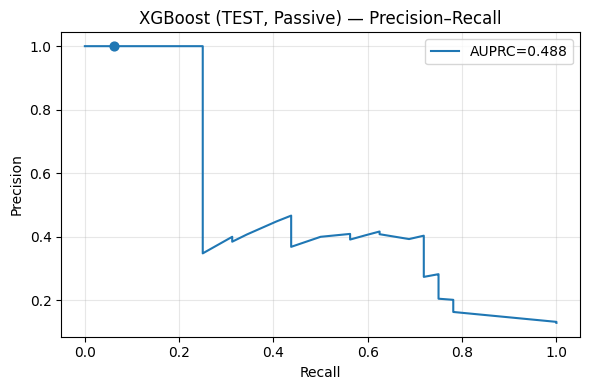

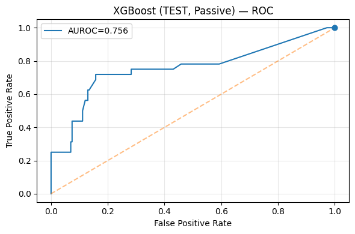

**Active XGBoost**

- **PR curve**: More balanced precision-recall trade-off with higher sensitivity.
- **ROC curve**: Shows strong performance across thresholds.

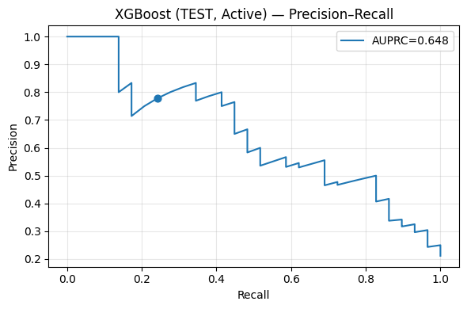

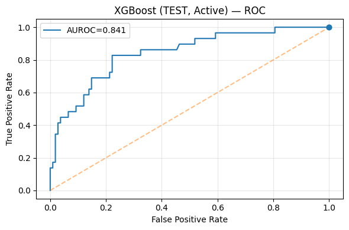

### **Key takeaways**

- **Active features** (questionnaire data) outperform **passive HR** in terms of both AUROC and AUPRC.
- **XGBoost** consistently outperformed logistic regression in both models.
- **Passive HR** showed moderate discrimination but had low sensitivity, limiting its standalone use for clinical decision-making.

## **Interpretability**

Model interpretability was assessed using **SHAP (SHapley Additive exPlanations)** to understand which features most influenced predictions.

### **SHAP feature importance and summary**

The helper function `shap_topk_plots()` produces two complementary plots for each model:

1. **Bar plot (top-k mean |SHAP| values)** — shows which features contribute most on average.
2. **Beeswarm plot** — shows how feature values influence the prediction direction (positive vs. negative impact).

**Passive XGBoost (HR)**

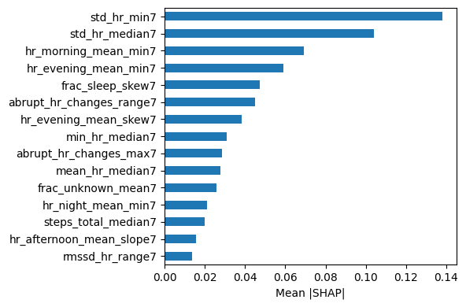

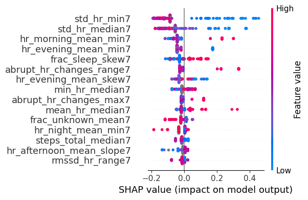

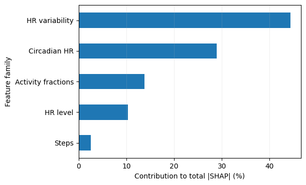

**Active XGBoost (questionnaire)**

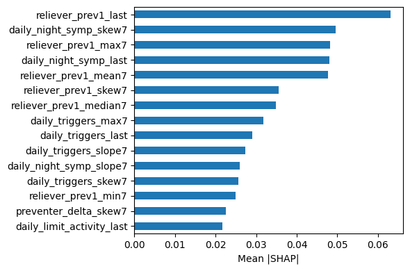

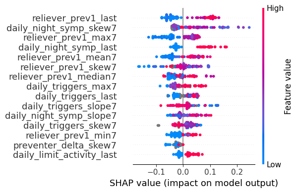

## **Sensitivity Analyses**

Sensitivity analyses tested how stable model performance was under alternative design and data assumptions.  
Each scenario reused the same end-to-end pipeline but changed one or more configuration parameters.

### **Scenarios tested**

[output not shown]

### **Passive XGBoost — Sensitivity results**

Changes in predictive performance (AUROC and AUPRC) for the **passive HR-only model** under different parameter settings.

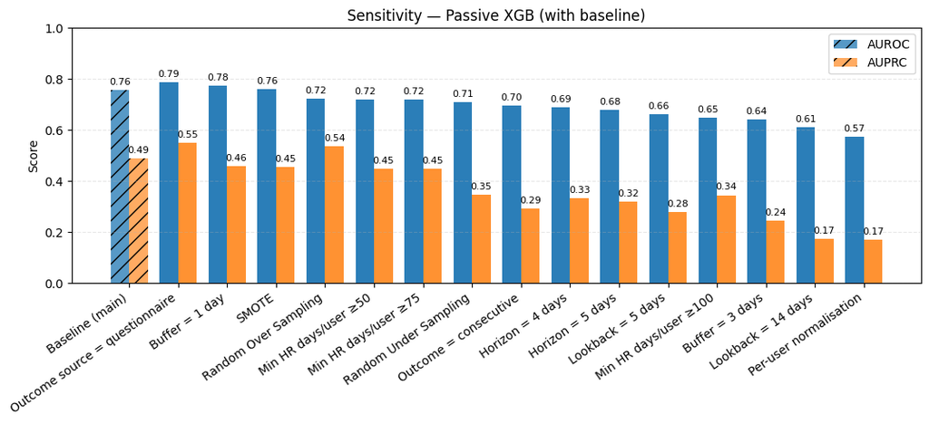

### **Active XGBoost — Sensitivity results**

Equivalent analysis for the **active (questionnaire-based)** model.

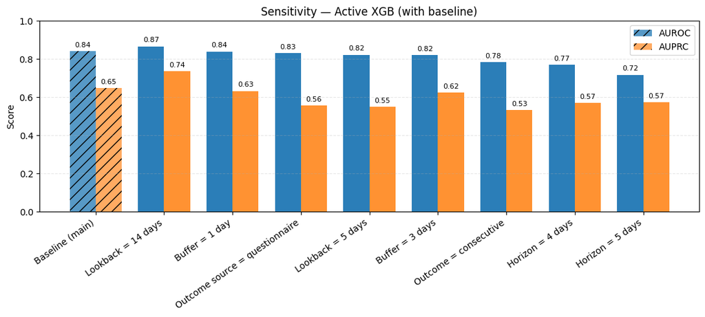

**Interpretation:**  
The active model showed greater robustness across all variations.

## **Limitations**

Several factors limit the generalisability of these findings:

- **Outcome capture:** Exacerbations were labelled from reliever inhaler actuations, a clinically recognised marker of worsening asthma. However, incomplete capture may have occurred if participants used non-monitored devices or syncing failed, potentially misclassifying zero-use days. Sensitivity analyses using self-reported reliever use confirmed robustness to this risk.
- **Device missingness:** Weekly smartwatch syncing meant data collection was not fully passive. Gaps in heart-rate coverage required imputation, which may have attenuated short-term variability and reduced sensitivity to acute physiological changes.
- **Cohort size and composition:** The study involved a small, selective sample (n = 22) of adults with severe asthma actively engaged in digital monitoring. This limits robustness and external validity to milder disease, different treatment regimens, and populations with lower digital literacy.
- **Temporal and contextual factors:** Data were collected during the COVID-19 pandemic, which likely reduced exposure to environmental triggers and lowered event frequency—potentially weakening model signal.
- **Lack of external validation:** Models were trained and evaluated solely within the AAMOS-00 dataset. Broader validation on independent cohorts and devices is required before clinical deployment.

Despite these constraints, the study’s structured temporal framework, leakage-safe evaluation, and extensive sensitivity analyses provide a credible foundation for future research on passive HR-based exacerbation prediction.